# 2019.11.6 복습 과제

## 3-1

> 주어진 자료를 height라는 객체로 지정하고, 히스토그램과 boxplot을 이용하여, 정규분포 모양을 이루는지 말하여라.

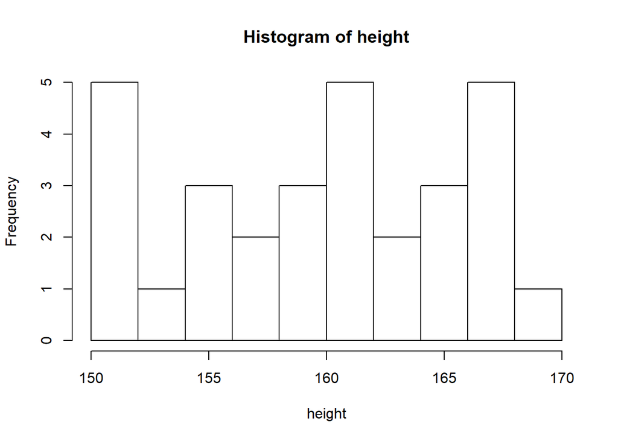

```r
hist(height,breaks=10)
```

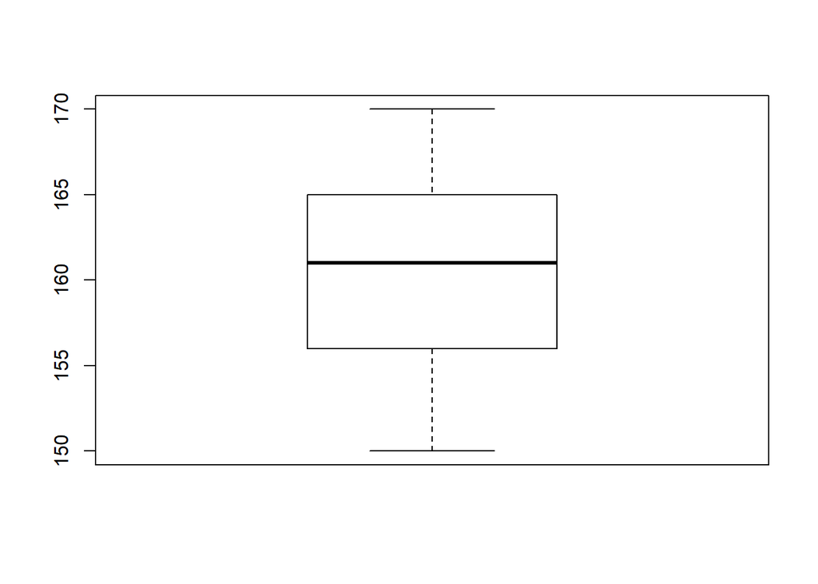

```r
boxplot(height)
```

> 상자그림을 통해서는 양쪽이 대칭인 정규분포를 예상할 수 있으나, 히스토그램 모양으로 보아, 정규분포 모양처럼 보이지는 않다.

## 3-2

> 다음 자료의 정규성을 확인해보고자 한다. 왜도와 첨도를 구하고 차트를 이용하여 정규성을 판단하라.

```r
library(moments)

skewness(height)
```

```
## [1] -0.1782455
```

```r
kurtosis(height)
```

```
## [1] 1.931449
```

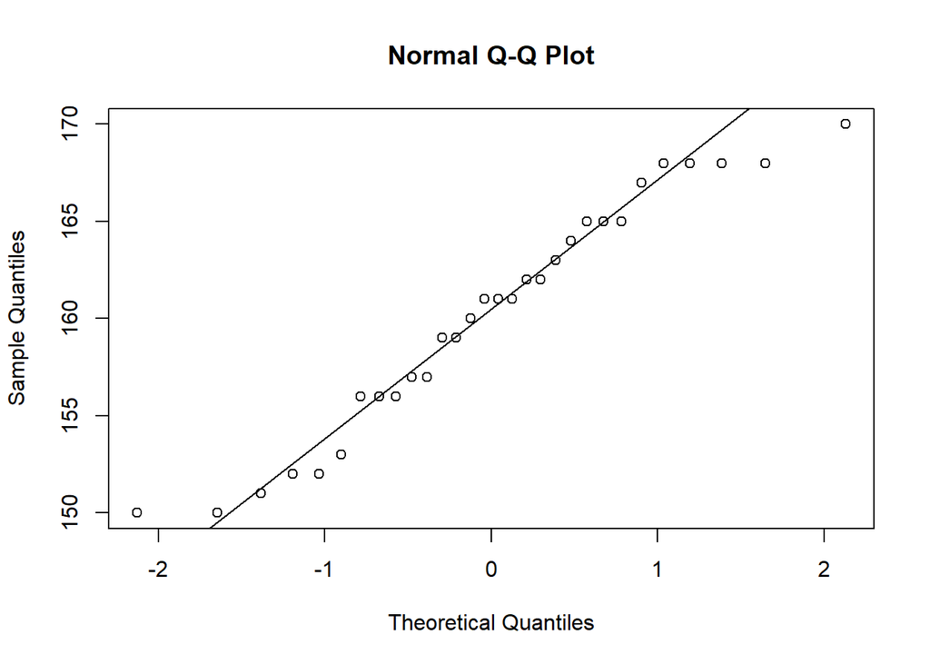

```r
qqnorm(height)
qqline(height)
```

> 왜도가 0에 가깝고 첨도 또한 10을 넘지 않는다. 정규성 차트를 적합했을때 직선과 일치하는 모양이므로, height는 정규성을 만족한다고 볼 수 있다.

## 4. 주사위를 1000번 던지는 실험을 통해 주사위를 던지는 시행이 정규분포를 따르는지

## 주사위 눈금의 난수를 추출하고 상자그림, 히스토그램을 이용해 판단하라.

> hint : sample, qqplot

```r
dice=c(1,2,3,4,5,6)

set.seed(7777)
data=sample(dice,1000,replace = T)
data
```

[output not shown]

```r
data
```

[output not shown]

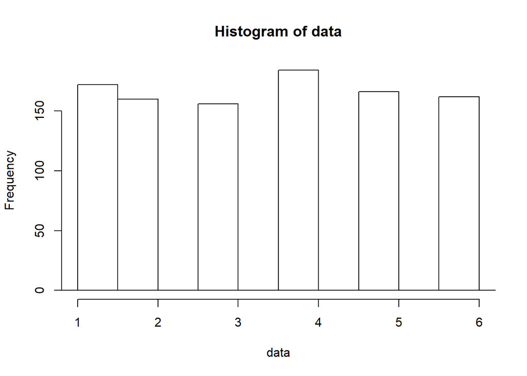

```r
hist(data)

lines(density(data))
```

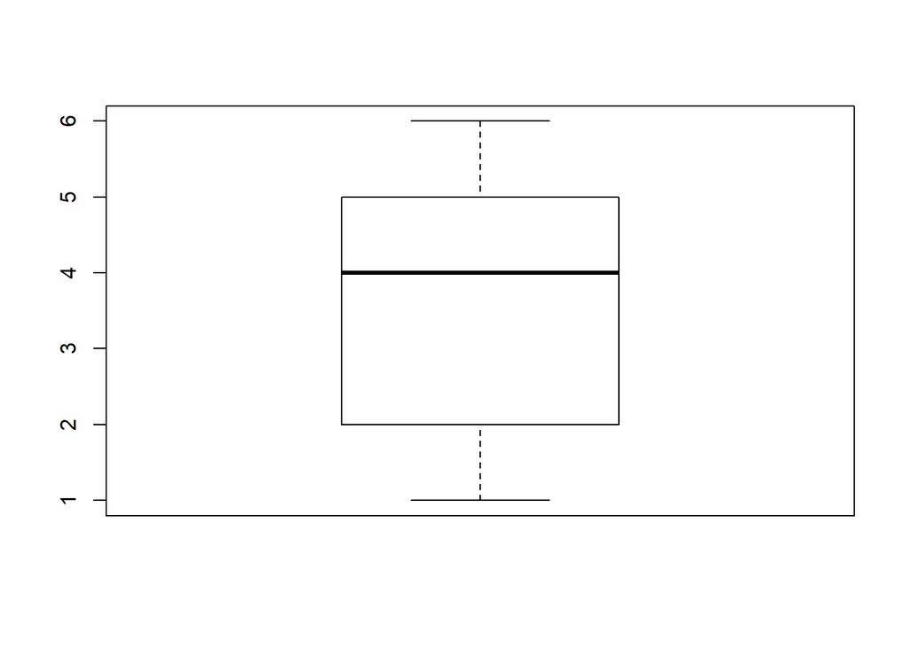

```r
boxplot(data)
```

```r
skewness(data)
```

```
## [1] -0.02322721
```

```r
kurtosis(data)
```

```
## [1] 1.742787
```

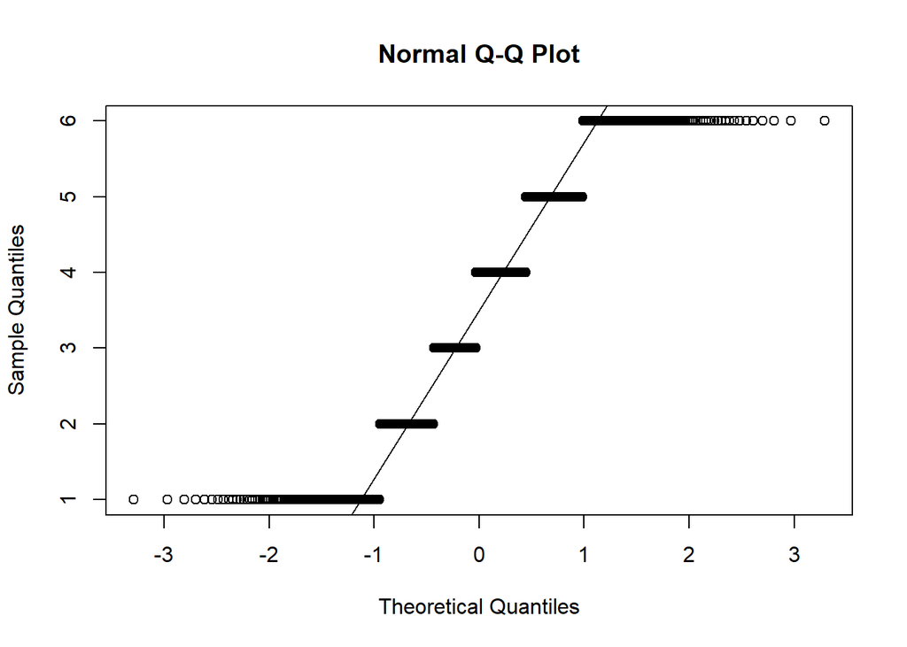

```r
qqnorm(data)
qqline(data)
```

## 5. 카이제곱분포의 그래프를 그리고자 한다.

## 그림과 같은 결과의 차트를 그려라.

> plot(x,y,type=“n”)

> 범주 : legend(위치, bty = ‘n’, ncol = 8, lty = , col = , legend = c(‘k=1’, ‘k=2’, ‘k=3’, ‘k=4’, ‘k=5’, ‘k=10’, ‘k=20’, ‘k=30’))

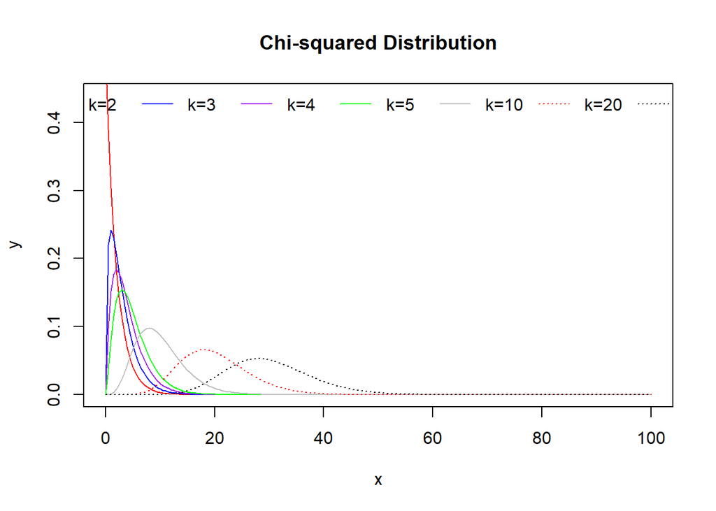

```r
x <- seq(0, 100, length=201)

y=dchisq(x,1)


y2 <- dchisq(x, 2)
y3 <- dchisq(x, 3)
y4 <- dchisq(x, 4)
y5 <- dchisq(x, 5)
y10 <- dchisq(x, 10)
y20 <- dchisq(x, 20)
y30 <- dchisq(x, 30)

plot(x,y,type="n",main="Chi-squared Distribution",ylab="y",
xlim=c(0,100))

lines(x, y2, col = 'red')
lines(x, y3, col = 'blue')
lines(x, y4, col = 'purple')
lines(x, y5, col = 'green')
lines(x, y10, col = 'grey')
lines(x, y20, col = 'red', lty = 3)
lines(x, y30, col = 'black', lty = 3)


legend('top', bty="n",ncol = 7,
       lty = c(1,1,1,1,1,3,3),
       col = c('red', 'blue', 'purple', 'green', 'grey', 'red', 'black'),
       legend = c('k=2', 'k=3', 'k=4', 'k=5', 'k=10', 'k=20', 'k=30'))
```